# Continuous Biomarker Evaluation for GLM Outcomes

- Show All Code
- Hide All Code
- View Source

Comparing glm_cs_fit, MFPI, and STEPP-GLM on Binary and Count Endpoints

Author

ForestSearch Package Documentation

Published

March 26, 2026

```r
# Load the installed forestsearch (for cox_cs_fit and other exports)
library(forestsearch)

# Source new GLM functions not yet exported from the package
# glm_cs_fit() and glm_effect_estimators
pkg_root <- getwd()
while (!file.exists(file.path(pkg_root, "DESCRIPTION")) &&
       pkg_root != dirname(pkg_root)) {
  pkg_root <- dirname(pkg_root)
}
stopifnot("Could not find package root" = file.exists(
  file.path(pkg_root, "DESCRIPTION")))

source(file.path(pkg_root, "R", "glm_spline_fit.R"))
source(file.path(pkg_root, "R", "glm_effect_estimators.R"))

# Path for parallel workers to source glm_cs_fit
glm_source_path <- file.path(pkg_root, "R", "glm_spline_fit.R")

library(survival)
library(splines)
library(mfp)
library(ggplot2)
library(patchwork)
library(scales)
library(dplyr)
library(doFuture)
library(foreach)

cat("glm_cs_fit available:", is.function(glm_cs_fit), "\n")
```

```
glm_cs_fit available: TRUE
```

**NoteRelationship to the Survival Biomarker Vignette**

This document is the **GLM counterpart** to the survival-endpoint continuous biomarker evaluation vignette (`biomarker_comparison.qmd`). It applies the same three-method comparison framework — spline interaction model, MFPI, and STEPP — to **binary** and **count** outcomes rather than time-to-event endpoints.

**New package function (in development):** `glm_cs_fit()` is the GLM analog of `cox_cs_fit()`. It is sourced from `R/glm_spline_fit.R` for this vignette and will be exported in a future release. It fits a natural-spline treatment–biomarker interaction GLM and produces a treatment-effect profile with delta-method CIs, directly paralleling the log-HR profile from `cox_cs_fit()`.

| Survival Version | GLM Version | Effect Scale |
| --- | --- | --- |
| `cox_cs_fit()` | `glm_cs_fit()` | log-OR, log-IRR, or MD |
| MFPI (`family = cox`) | MFPI (`family = binomial`) | log-OR TEF |
| STEPP (`stmodelKM`) | STEPP (`stmodelGLM`) | Risk or OR profile |

# 1 Overview

A continuously-measured biomarker may **modify a treatment effect** on binary, count, or continuous outcomes. Three methods address this:

| Method | Core Idea | Link to R |
| --- | --- | --- |
| **`glm_cs_fit()`** | Natural-spline interaction GLM; returns profile + CIs | `forestsearch` (new) |
| **MFPI** | FP functions fit per arm; difference is the TEF | `mfp` (CRAN) |
| **STEPP-GLM** | Model-free GLM estimates in sliding windows | `stepp` (CRAN) |

This vignette applies all three to:

1. The **GBSG dataset** with a binary recurrence endpoint, examining whether progesterone receptor (PGR) predicts hormonal therapy benefit on the log-odds scale.
2. Four **synthetic simulation scenarios** with known logistic interaction functions, evaluating SE calibration, coverage, and CI width for `glm_cs_fit()` and STEPP-GLM.

**TipTo-Do: Poisson/Count Extension**

The `stepp` CRAN package already supports `stmodelGLM` with `glm = "poisson"` for count data, and `glm_cs_fit()` accepts `family = "poisson"` with an offset. A future section will add:

- GBSG analysis with Poisson rate model (event count + log-time offset)
- Simulation with known incidence-rate interaction functions
- IRR profiles from all three methods
- Comparison to `cox_cs_fit()` HR profiles on the same data (QC)

# 2 GBSG Dataset Analysis

## 2.1 Data Preparation

```r
data("gbsg", package = "survival")

gbsg <- gbsg |>
  mutate(
    rfstime_yr = rfstime / 365.25,
    log_pgr    = log(pgr + 1),
    treat      = hormon
  )

cat(sprintf(
  "N = %d  |  Events = %d (%.1f%%)  |  Hormon n = %d  |  Control n = %d\n",
  nrow(gbsg), sum(gbsg$status), 100 * mean(gbsg$status),
  sum(gbsg$treat == 1), sum(gbsg$treat == 0)
))
```

```
N = 686  |  Events = 299 (43.6%)  |  Hormon n = 246  |  Control n = 440
```

```r
# Overall log-OR (logistic regression)
fit_logistic_itt <- glm(status ~ treat, family = binomial, data = gbsg)
logor_itt        <- coef(fit_logistic_itt)["treat"]
ci_logor_itt     <- confint.default(fit_logistic_itt)["treat", ]

cat(sprintf(
  "Overall OR (hormon vs control): %.3f  (95%% CI: %.3f -- %.3f)\n",
  exp(logor_itt), exp(ci_logor_itt[1]), exp(ci_logor_itt[2])
))
```

```
Overall OR (hormon vs control): 0.709  (95% CI: 0.516 -- 0.974)
```

```r
# Also compute overall log-HR for reference/comparison
fit_cox_itt <- coxph(Surv(rfstime_yr, status) ~ treat, data = gbsg)
loghr_itt   <- coef(fit_cox_itt)["treat"]
cat(sprintf(
  "Overall HR (for reference): %.3f\n", exp(loghr_itt)
))
```

```
Overall HR (for reference): 0.695
```

## 2.2 Biomarker Distribution

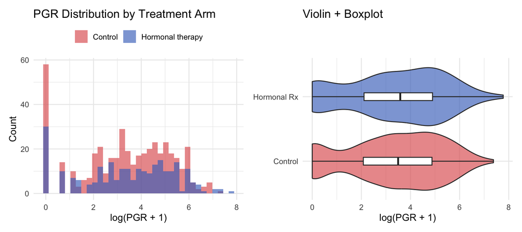

Distribution of log(PGR+1) by treatment arm.

```r
p_hist <- ggplot(gbsg, aes(x = log_pgr, fill = factor(treat))) +
  geom_histogram(bins = 35, alpha = 0.65, position = "identity") +
  scale_fill_manual(values  = c("#E05C5C", "#4472C4"),
                    labels  = c("Control", "Hormonal therapy")) +
  labs(x = "log(PGR + 1)", y = "Count", fill = NULL,
       title = "PGR Distribution by Treatment Arm") +
  theme_minimal(base_size = 12) +
  theme(legend.position = "top")

p_box <- ggplot(
  gbsg,
  aes(x = log_pgr,
      y = factor(treat, labels = c("Control", "Hormonal Rx")),
      fill = factor(treat))
) +
  geom_violin(alpha = 0.65, show.legend = FALSE) +
  geom_boxplot(width = 0.12, outlier.size = 0.7,
               fill = "white", show.legend = FALSE) +
  scale_fill_manual(values = c("#E05C5C", "#4472C4")) +
  labs(x = "log(PGR + 1)", y = NULL, title = "Violin + Boxplot") +
  theme_minimal(base_size = 12)

p_hist + p_box + plot_layout(ncol = 2)
```

## 2.3 Shared Biomarker Grid

```r
z_grid <- seq(
  quantile(gbsg$log_pgr, 0.05),
  quantile(gbsg$log_pgr, 0.95),
  length.out = 200L
)
nd_grid <- data.frame(log_pgr = z_grid)
```

## 2.4 Method 1: `glm_cs_fit()` from `forestsearch`

The GLM spline model:

$$\text{logit}\bigl(P(Y=1 \mid Z, A)\bigr) = \beta_0 A + f(Z) + g(Z) \cdot A$$

where $Z = \log(\text{pgr}+1)$, $A$ = treatment. The log-OR profile is $\hat\beta(Z) = \hat\beta_0 + \hat g(Z)$ with delta-method CIs.

```r
fit_gcsf <- glm_cs_fit(
  df          = gbsg,
  outcome_name = "status",
  treat_name   = "treat",
  z_name       = "log_pgr",
  family       = "binomial",
  spline_df    = sim_spline_df,
  z_by         = 0.05,
  z_quantile   = 0.95,
  alpha        = sim_alpha,
  show_plot    = FALSE,
  verbose      = TRUE
)
```

```
=== GLM Spline Fit ===
Family: binomial  | Effect: log(OR)
Z range: 0 7.775
Prediction grid: 121 points from 0 to 6
N = 686  | Events = 299

--- Primary GLM (no interaction) ---
log(OR) : -0.344
Exponentiated: 0.7089

--- LRT for treat x ns( log_pgr ) interaction ---
Chi-sq = 5.23 , df = 3 , p = 0.1556

--- Treatment-Effect Profile ---
log(OR) range: -1.1238 to 0.0578
```

```r
df_gcsf <- data.frame(
  z      = fit_gcsf$z_profile,
  pgr    = exp(fit_gcsf$z_profile) - 1,
  loghr  = fit_gcsf$loghr_est,
  lo     = fit_gcsf$loghr_lower,
  hi     = fit_gcsf$loghr_upper,
  method = "glm_cs_fit (forestsearch)"
)
```

## 2.5 Method 1b: Manual Spline Logistic (for Transparency)

```r
spline_df <- sim_spline_df

fit_logistic_spline <- glm(
  status ~ treat + ns(log_pgr, df = spline_df) +
    ns(log_pgr, df = spline_df):treat,
  family = binomial, data = gbsg
)

fit_logistic_main <- glm(
  status ~ treat + ns(log_pgr, df = spline_df),
  family = binomial, data = gbsg
)

lrt_logistic <- anova(fit_logistic_main, fit_logistic_spline, test = "Chisq")
cat(sprintf(
  "LRT for treat x ns(log_pgr): Chi-sq = %.2f, df = %d, p = %.4f\n",
  lrt_logistic$Deviance[2],
  lrt_logistic$Df[2],
  lrt_logistic[2, "Pr(>Chi)"]
))
```

```
LRT for treat x ns(log_pgr): Chi-sq = 5.23, df = 3, p = 0.1556
```

```r
nd1 <- data.frame(log_pgr = z_grid, treat = 1, status = 0L)
nd0 <- data.frame(log_pgr = z_grid, treat = 0, status = 0L)

lp1_manual <- predict(fit_logistic_spline, newdata = nd1, type = "link")
lp0_manual <- predict(fit_logistic_spline, newdata = nd0, type = "link")

X1 <- model.matrix(fit_logistic_spline, data = nd1)
X0 <- model.matrix(fit_logistic_spline, data = nd0)
Xdiff <- X1 - X0

logor_manual <- as.numeric(Xdiff %*% coef(fit_logistic_spline))
se_manual    <- sqrt(diag(Xdiff %*% vcov(fit_logistic_spline) %*% t(Xdiff)))

df_manual <- data.frame(
  z      = z_grid,
  pgr    = exp(z_grid) - 1,
  loghr  = logor_manual,
  lo     = logor_manual - 1.96 * se_manual,
  hi     = logor_manual + 1.96 * se_manual,
  method = "Manual Spline Logistic"
)

# Agreement check
shared_z <- intersect(round(df_gcsf$z, 3), round(df_manual$z, 3))
if (length(shared_z) > 0) {
  idx_g <- match(round(shared_z[1], 3), round(df_gcsf$z, 3))
  idx_m <- match(round(shared_z[1], 3), round(df_manual$z, 3))
  cat(sprintf(
    "Agreement at Z = %.3f: glm_cs_fit = %.4f, manual = %.4f (diff = %.2e)\n",
    shared_z[1], df_gcsf$loghr[idx_g], df_manual$loghr[idx_m],
    abs(df_gcsf$loghr[idx_g] - df_manual$loghr[idx_m])
  ))
}
```

```
Agreement at Z = 0.000: glm_cs_fit = -0.0560, manual = -0.0560 (diff = 0.00e+00)
```

## 2.6 Method 2: MFPI (Logistic)

MFPI with `family = binomial` fits fractional polynomial prognostic functions per arm and takes the difference as the treatment-effect function (TEF).

```r
fit_mfp0 <- mfp(status ~ fp(log_pgr, df = 4),
                data = filter(gbsg, treat == 0),
                family = binomial, verbose = FALSE)

fit_mfp1 <- mfp(status ~ fp(log_pgr, df = 4),
                data = filter(gbsg, treat == 1),
                family = binomial, verbose = FALSE)

cat("FP powers -- Control:", fit_mfp0$powers[, "power1"],
    " | Hormon:", fit_mfp1$powers[, "power1"], "\n")
```

```
FP powers -- Control: 1  | Hormon: 1
```

```r
lp0_mfp <- predict(fit_mfp0, newdata = nd_grid, type = "link")
lp1_mfp <- predict(fit_mfp1, newdata = nd_grid, type = "link")

raw_mfp   <- lp1_mfp - lp0_mfp
logor_mfp <- raw_mfp - mean(raw_mfp) + logor_itt

# Bootstrap CIs
set.seed(2024L)
n_boot <- sim_n_boot_mfpi
boot_mat <- matrix(NA_real_, nrow = n_boot, ncol = length(z_grid))

for (b in seq_len(n_boot)) {
  idx  <- sample(nrow(gbsg), replace = TRUE)
  bdat <- gbsg[idx, ]

  f0b <- tryCatch(
    mfp(status ~ fp(log_pgr, df = 4),
        data = filter(bdat, treat == 0), family = binomial, verbose = FALSE),
    error = function(e) NULL
  )
  f1b <- tryCatch(
    mfp(status ~ fp(log_pgr, df = 4),
        data = filter(bdat, treat == 1), family = binomial, verbose = FALSE),
    error = function(e) NULL
  )
  if (is.null(f0b) || is.null(f1b)) next

  lp0b <- tryCatch(predict(f0b, newdata = nd_grid, type = "link"),
                   error = function(e) NULL)
  lp1b <- tryCatch(predict(f1b, newdata = nd_grid, type = "link"),
                   error = function(e) NULL)
  if (is.null(lp0b) || is.null(lp1b)) next

  raw_b         <- lp1b - lp0b
  boot_mat[b, ] <- raw_b - mean(raw_b) + logor_itt
}

n_valid <- sum(complete.cases(boot_mat))
cat(sprintf("Bootstrap: %d/%d valid resamples\n", n_valid, n_boot))
```

```
Bootstrap: 200/200 valid resamples
```

```r
df_mfpi <- data.frame(
  z      = z_grid,
  pgr    = exp(z_grid) - 1,
  loghr  = logor_mfp,
  lo     = apply(boot_mat, 2, quantile, probs = 0.025, na.rm = TRUE),
  hi     = apply(boot_mat, 2, quantile, probs = 0.975, na.rm = TRUE),
  method = "MFPI (logistic)"
)
```

## 2.7 Method 3: STEPP-GLM

### 2.7.1 STEPP with GLM for Binary Outcomes

The `stepp` CRAN package supports `stmodelGLM` with `glm = "binomial"`. Within each sliding window, a logistic regression `event ~ treat` is fitted and the log-OR is extracted.

```r
# =============================================================================
# stepp_windows_glm() -- logistic sliding window fallback
# =============================================================================
stepp_windows_glm <- function(df, bm_var, outcome_var, treat_var,
                              family     = "binomial",
                              offset_var = NULL,
                              patspop    = sim_patspop,
                              minpatspop = sim_minpatspop,
                              conf_level = 1 - sim_alpha) {
  stopifnot(patspop > minpatspop)
  z_crit <- qnorm(1 - (1 - conf_level) / 2)
  df_ord <- df[order(df[[bm_var]]), ]
  n      <- nrow(df_ord)
  step   <- patspop - minpatspop
  starts <- seq(1L, n - patspop + 1L, by = step)

  fam <- switch(family,
    binomial = stats::binomial(),
    poisson  = stats::poisson(),
    gaussian = stats::gaussian()
  )

  rows <- lapply(starts, function(i) {
    sub <- df_ord[seq(i, i + patspop - 1L), ]
    fit <- tryCatch({
      if (!is.null(offset_var)) {
        stats::glm(
          as.formula(sprintf("%s ~ %s", outcome_var, treat_var)),
          family = fam, data = sub,
          offset = log(sub[[offset_var]])
        )
      } else {
        stats::glm(
          as.formula(sprintf("%s ~ %s", outcome_var, treat_var)),
          family = fam, data = sub
        )
      }
    }, error = function(e) NULL)

    if (is.null(fit)) return(NULL)
    b  <- coef(fit)[[treat_var]]
    se <- sqrt(vcov(fit)[treat_var, treat_var])
    data.frame(
      mid_bm   = median(sub[[bm_var]]),
      n_sub    = patspop,
      n_events = sum(sub[[outcome_var]]),
      loghr    = b,
      se_loghr = se,
      lo       = b - z_crit * se,
      hi       = b + z_crit * se,
      method   = paste0("STEPP-GLM (", family, ")")
    )
  })
  do.call(rbind, Filter(Negate(is.null), rows))
}


# =============================================================================
# stepp_fit_glm() -- unified STEPP-GLM wrapper
# =============================================================================
stepp_fit_glm <- function(df,
                          outcome_name = "event",
                          treat_name   = "treat",
                          bm_name      = "bm",
                          family       = "binomial",
                          offset_name  = NULL,
                          patspop      = sim_patspop,
                          minpatspop   = sim_minpatspop,
                          nperm        = 0L,
                          conf_level   = 1 - sim_alpha,
                          verbose      = TRUE) {

  z_crit <- qnorm(1 - (1 - conf_level) / 2)

  # Branch: stepp CRAN package with stmodelGLM
  if (requireNamespace("stepp", quietly = TRUE) && nperm > 0) {
    suppressPackageStartupMessages(library(stepp))
    if (verbose) message("stepp_fit_glm: using stepp CRAN stmodelGLM")

    swin <- new("stwin", type = "sliding",
                r1 = minpatspop, r2 = patspop)
    subp <- new("stsubpop")
    subp <- generate(subp, win = swin, covariate = df[[bm_name]])

    smod <- new("stmodelGLM",
                coltrt = df[[treat_name]],
                colY   = df[[outcome_name]],
                trts   = c(1, 0),
                glm    = family)

    res <- new("steppes")
    res <- estimate(res, subp, smod)

    if (nperm > 0L) {
      res <- test(res, nperm = as.integer(nperm), showstatus = FALSE)
    }

    bm_profile  <- res@subpop@medianz
    loghr_est   <- res@effect$Logistic[[1]]$logOddsRatio
    se_loghr    <- res@effect$Logistic[[1]]$logOddsRatioSE
    pv_overall  <- if (nperm > 0) res@testresults$Res[[1]]$pvalue else NA_real_
    method_used <- "stepp_cran_glm"

  } else {
    # Fallback: manual sliding window GLM
    if (verbose) message("stepp_fit_glm: using GLM fallback")

    fb <- stepp_windows_glm(
      df = df, bm_var = bm_name, outcome_var = outcome_name,
      treat_var = treat_name, family = family, offset_var = offset_name,
      patspop = patspop, minpatspop = minpatspop, conf_level = conf_level
    )

    bm_profile  <- fb$mid_bm
    loghr_est   <- fb$loghr
    se_loghr    <- fb$se_loghr
    pv_overall  <- NA_real_
    method_used <- "stepp_windows_glm"
  }

  loghr_lower <- loghr_est - z_crit * se_loghr
  loghr_upper <- loghr_est + z_crit * se_loghr

  result <- list(
    bm_profile  = bm_profile,
    loghr_est   = loghr_est,
    se_loghr    = se_loghr,
    loghr_lower = loghr_lower,
    loghr_upper = loghr_upper,
    n_windows   = length(bm_profile),
    pvalue      = pv_overall,
    method_used = method_used,
    family      = family,
    conf_level  = conf_level,
    nperm       = nperm,
    bm_name     = bm_name
  )
  class(result) <- c("stepp_fit_glm", "list")

  if (verbose) {
    cat(sprintf(
      "stepp_fit_glm [%s]: %d windows | log-OR range: %.3f to %.3f\n",
      method_used, result$n_windows,
      min(loghr_est, na.rm = TRUE), max(loghr_est, na.rm = TRUE)
    ))
    if (!is.na(pv_overall)) {
      cat(sprintf("  Permutation p-value: %.4f\n", pv_overall))
    }
  }

  invisible(result)
}
```

```r
fit_stepp_glm_gbsg <- stepp_fit_glm(
  df          = gbsg,
  outcome_name = "status",
  treat_name   = "treat",
  bm_name      = "log_pgr",
  family       = "binomial",
  patspop      = sim_patspop,
  minpatspop   = sim_minpatspop,
  nperm        = 0L,
  conf_level   = 1 - sim_alpha
)
```

```
stepp_fit_glm [stepp_windows_glm]: 6 windows | log-OR range: -1.438 to 0.125
```

```r
df_stepp_gbsg <- data.frame(
  mid_bm = fit_stepp_glm_gbsg$bm_profile,
  loghr  = fit_stepp_glm_gbsg$loghr_est,
  lo     = fit_stepp_glm_gbsg$loghr_lower,
  hi     = fit_stepp_glm_gbsg$loghr_upper,
  method = "STEPP-GLM"
)
```

## 2.8 Combined Results: GBSG (Binary Endpoint)

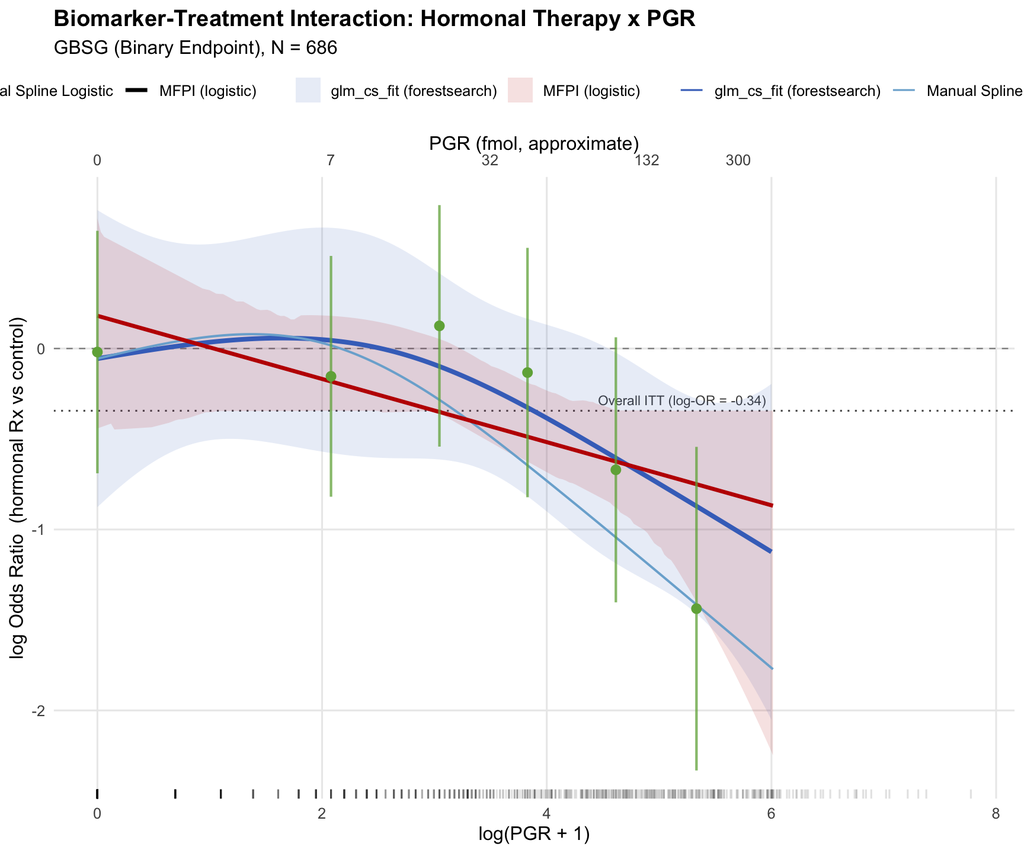

Treatment-effect (log-OR) profile for hormonal therapy vs control as a function of log(PGR+1) on the binary recurrence endpoint. All methods agree that benefit (negative log-OR) is concentrated at higher PGR values.

```r
col_map <- c(
  "glm_cs_fit (forestsearch)" = "#4472C4",
  "Manual Spline Logistic"     = "#7BAFD4",
  "MFPI (logistic)"            = "#C00000",
  "STEPP-GLM"                  = "#70AD47"
)
lwd_map <- c(
  "glm_cs_fit (forestsearch)" = 1.4,
  "Manual Spline Logistic"     = 0.7,
  "MFPI (logistic)"            = 1.2,
  "STEPP-GLM"                  = 1.0
)
pgr_ticks <- c(0, 7, 32, 132, 300)

df_ribbon <- bind_rows(df_gcsf, df_manual, df_mfpi)

ggplot() +
  geom_hline(yintercept = 0, linetype = "dashed",
             colour = "grey55", linewidth = 0.40) +
  geom_hline(yintercept = logor_itt, linetype = "dotted",
             colour = "grey35", linewidth = 0.55) +
  annotate("text",
           x     = max(z_grid) * 0.99, y = logor_itt + 0.06,
           label = sprintf("Overall ITT (log-OR = %.2f)", logor_itt),
           hjust = 1, size = 3.0, colour = "grey30") +
  geom_ribbon(data = filter(df_ribbon,
                            method %in% c("glm_cs_fit (forestsearch)",
                                          "MFPI (logistic)")),
              aes(x = z, ymin = lo, ymax = hi, fill = method), alpha = 0.12) +
  geom_line(data = df_ribbon,
            aes(x = z, y = loghr, colour = method, linewidth = method)) +
  geom_linerange(data = df_stepp_gbsg,
                 aes(x = mid_bm, ymin = lo, ymax = hi, colour = method),
                 linewidth = 0.75, alpha = 0.75) +
  geom_point(data = df_stepp_gbsg,
             aes(x = mid_bm, y = loghr, colour = method),
             size = 2.8, shape = 16) +
  geom_rug(data = gbsg, aes(x = log_pgr),
           alpha = 0.12, sides = "b", length = unit(0.015, "npc")) +
  scale_colour_manual(values = col_map, name = NULL) +
  scale_fill_manual(values = col_map, name = NULL) +
  scale_linewidth_manual(values = lwd_map, name = NULL) +
  scale_x_continuous(
    name = "log(PGR + 1)",
    sec.axis = sec_axis(~ exp(.) - 1,
                        name   = "PGR (fmol, approximate)",
                        breaks = pgr_ticks, labels = pgr_ticks)
  ) +
  labs(y     = "log Odds Ratio  (hormonal Rx vs control)",
       title = "Biomarker-Treatment Interaction: Hormonal Therapy x PGR",
       subtitle = "GBSG (Binary Endpoint), N = 686") +
  theme_minimal(base_size = 12) +
  theme(legend.position  = "top",
        panel.grid.minor = element_blank(),
        plot.title       = element_text(face = "bold"))
```

## 2.9 Comparison: log-OR vs log-HR Profile

Since the GBSG data supports both survival and binary analyses, we can overlay the `glm_cs_fit()` log-OR profile with the `cox_cs_fit()` log-HR profile on the same data. Under proportional hazards, these should show similar qualitative patterns.

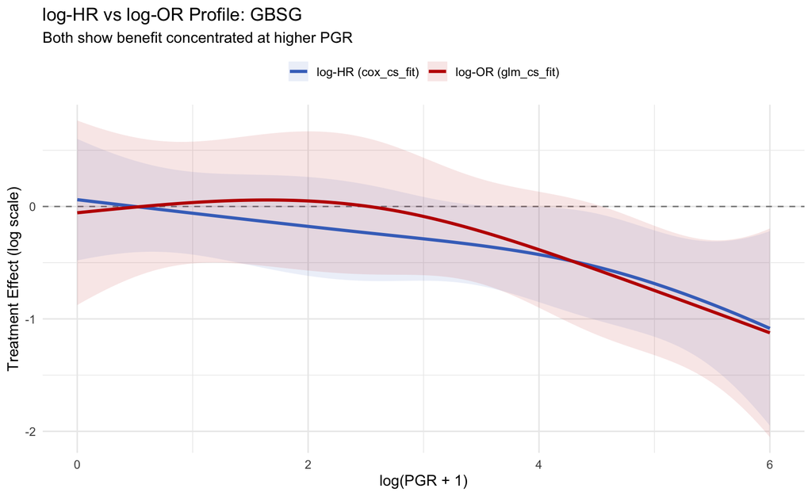

Overlay of log-HR (from cox_cs_fit, survival endpoint) and log-OR (from glm_cs_fit, binary endpoint) profiles. The qualitative shape agrees: both show increasing benefit at higher PGR.

```r
gbsg_fs <- gbsg |>
  rename(os_time = rfstime_yr, os_event = status) |>
  mutate(bm = log_pgr)

fit_ccsf_compare <- cox_cs_fit(
  df = gbsg_fs, tte_name = "os_time", event_name = "os_event",
  treat_name = "treat", z_name = "bm",
  spline_df = sim_spline_df, z_by = 0.05, z_quantile = 0.95,
  alpha = sim_alpha, show_plot = FALSE, verbose = FALSE
)

df_hr <- data.frame(
  z = fit_ccsf_compare$z_profile,
  est = fit_ccsf_compare$loghr_est,
  lo  = fit_ccsf_compare$loghr_lower,
  hi  = fit_ccsf_compare$loghr_upper,
  scale = "log-HR (cox_cs_fit)"
)
df_or <- data.frame(
  z = fit_gcsf$z_profile,
  est = fit_gcsf$loghr_est,
  lo  = fit_gcsf$loghr_lower,
  hi  = fit_gcsf$loghr_upper,
  scale = "log-OR (glm_cs_fit)"
)
df_compare <- bind_rows(df_hr, df_or)

ggplot(df_compare, aes(x = z, y = est, colour = scale, fill = scale)) +
  geom_hline(yintercept = 0, linetype = "dashed", colour = "grey55") +
  geom_ribbon(aes(ymin = lo, ymax = hi), alpha = 0.10, colour = NA) +
  geom_line(linewidth = 1.2) +
  scale_colour_manual(values = c("log-HR (cox_cs_fit)" = "#4472C4",
                                  "log-OR (glm_cs_fit)" = "#C00000"),
                      name = NULL) +
  scale_fill_manual(values = c("log-HR (cox_cs_fit)" = "#4472C4",
                                "log-OR (glm_cs_fit)" = "#C00000"),
                    name = NULL) +
  labs(x     = "log(PGR + 1)",
       y     = "Treatment Effect (log scale)",
       title = "log-HR vs log-OR Profile: GBSG",
       subtitle = "Both show benefit concentrated at higher PGR") +
  theme_minimal(base_size = 12) +
  theme(legend.position = "top")
```

# 3 Simulation Study: Known Ground Truth

## 3.1 Data Generating Mechanism (Logistic)

Four scenarios with known log-OR interaction functions:

| Scenario | True $\beta(Z)$ | Interpretation |
| --- | --- | --- |
| **A – Monotone** | $0.5 - 0.35\,Z$ | Benefit increases linearly |
| **B – Threshold** | $+0.35$ if $Z<2$; $-0.40$ if $Z \geq 2$ | Sharp sign reversal |
| **C – Null** | $-0.20$ (constant) | Uniform moderate benefit |
| **D – Non-monotone** | $-0.40(Z-1.8)^2 + 0.50$ | Harm peaks at $Z \approx 1.8$ |

$$P(Y=1 \mid Z, A) = \text{expit}\bigl(-1.5 - 0.20\,Z + \beta(Z) \cdot A\bigr)$$

```r
simulate_binary_trial <- function(n = 700L, scenario = "monotone", seed = 42L) {
  set.seed(seed)

  bm    <- rgamma(n, shape = 2, rate = 0.6)
  Z     <- log(bm + 1)
  treat <- rbinom(n, 1L, 0.5)

  true_logor <- switch(scenario,
    monotone    = 0.5 - 0.35 * Z,
    threshold   = ifelse(Z < 2.0, 0.35, -0.40),
    null        = rep(-0.20, n),
    nonmonotone = -0.40 * (Z - 1.8)^2 + 0.50,
    stop("Unknown scenario: ", scenario)
  )

  lp    <- -1.5 - 0.20 * Z + true_logor * treat
  prob  <- plogis(lp)
  event <- rbinom(n, 1L, prob)

  data.frame(
    event      = event,
    treat      = treat,
    bm         = bm,
    Z          = Z,
    true_logor = true_logor
  )
}

scenarios <- c("monotone", "threshold", "null", "nonmonotone")
dfs <- setNames(
  lapply(scenarios, function(sc) simulate_binary_trial(scenario = sc)),
  scenarios
)

for (sc in scenarios) {
  d <- dfs[[sc]]
  cat(sprintf(
    "%-12s  N=%d  events=%d (%.0f%%)  true log-OR range [%.2f, %.2f]\n",
    sc, nrow(d), sum(d$event), 100 * mean(d$event),
    min(d$true_logor), max(d$true_logor)
  ))
}
```

```
monotone      N=700  events=126 (18%)  true log-OR range [-0.46, 0.49]
threshold     N=700  events=144 (21%)  true log-OR range [-0.40, 0.35]
null          N=700  events=118 (17%)  true log-OR range [-0.20, -0.20]
nonmonotone   N=700  events=138 (20%)  true log-OR range [-0.77, 0.50]
```

## 3.2 Fit All Three Methods

```r
fit_all_methods_glm <- function(df, scenario_name) {

  z_range <- seq(quantile(df$Z, 0.05), quantile(df$Z, 0.95),
                 length.out = 150L)

  # -- glm_cs_fit --
  fit_gcsf_s <- tryCatch(
    glm_cs_fit(
      df = df, outcome_name = "event", treat_name = "treat",
      z_name = "Z", family = "binomial",
      spline_df = sim_spline_df, z_by = 0.05, z_quantile = 0.95,
      alpha = sim_alpha, show_plot = FALSE, verbose = FALSE
    ),
    error = function(e) NULL
  )

  df_gcsf_s <- if (!is.null(fit_gcsf_s)) {
    data.frame(z = fit_gcsf_s$z_profile, loghr = fit_gcsf_s$loghr_est,
               lo = fit_gcsf_s$loghr_lower, hi = fit_gcsf_s$loghr_upper,
               method = "glm_cs_fit", scenario = scenario_name)
  } else {
    data.frame(z = z_range, loghr = NA, lo = NA, hi = NA,
               method = "glm_cs_fit", scenario = scenario_name)
  }

  # -- MFPI (logistic) --
  logor_itt_s <- coef(glm(event ~ treat, family = binomial,
                          data = df))["treat"]

  lh_mfpi <- tryCatch({
    f0s <- mfp(event ~ fp(Z, df = 4),
               data = filter(df, treat == 0), family = binomial,
               verbose = FALSE)
    f1s <- mfp(event ~ fp(Z, df = 4),
               data = filter(df, treat == 1), family = binomial,
               verbose = FALSE)
    raw_s <- predict(f1s, newdata = data.frame(Z = z_range), type = "link") -
             predict(f0s, newdata = data.frame(Z = z_range), type = "link")
    raw_s - mean(raw_s) + logor_itt_s
  }, error = function(e) rep(NA_real_, length(z_range)))

  df_mfpi_s <- data.frame(z = z_range, loghr = lh_mfpi, lo = NA, hi = NA,
                           method = "MFPI", scenario = scenario_name)

  # -- STEPP-GLM --
  fit_st <- stepp_fit_glm(
    df = df, outcome_name = "event", treat_name = "treat",
    bm_name = "Z", family = "binomial",
    patspop = sim_patspop, minpatspop = sim_minpatspop,
    nperm = 0L, conf_level = 1 - sim_alpha, verbose = FALSE
  )
  df_st <- data.frame(mid_bm = fit_st$bm_profile, loghr = fit_st$loghr_est,
                      lo = fit_st$loghr_lower, hi = fit_st$loghr_upper,
                      method = "STEPP-GLM", scenario = scenario_name)

  # -- True log-OR --
  true_fn <- switch(scenario_name,
    monotone    = 0.5 - 0.35 * z_range,
    threshold   = ifelse(z_range < 2.0, 0.35, -0.40),
    null        = rep(-0.20, length(z_range)),
    nonmonotone = -0.40 * (z_range - 1.8)^2 + 0.50
  )
  df_truth <- data.frame(z = z_range, loghr = true_fn, lo = NA, hi = NA,
                         method = "True log-OR", scenario = scenario_name)

  list(gcsf = df_gcsf_s, mfpi = df_mfpi_s, stepp = df_st, truth = df_truth)
}

sim_res <- setNames(
  lapply(scenarios, function(sc) fit_all_methods_glm(dfs[[sc]], sc)),
  scenarios
)
```

## 3.3 Scenario Plots

```r
col_sim <- c("glm_cs_fit"  = "#4472C4",
             "MFPI"         = "#C00000",
             "STEPP-GLM"    = "#70AD47",
             "True log-OR"  = "black")
lty_sim <- c("glm_cs_fit"  = "solid",
             "MFPI"         = "solid",
             "STEPP-GLM"    = "solid",
             "True log-OR"  = "dashed")

plot_scenario_glm <- function(res, title, ylim = c(-1.4, 1.0)) {
  df_lines <- bind_rows(res$gcsf, res$mfpi, res$truth)

  ggplot() +
    geom_hline(yintercept = 0, linetype = "dotted",
               colour = "grey60", linewidth = 0.4) +
    geom_ribbon(data = res$gcsf,
                aes(x = z, ymin = lo, ymax = hi),
                fill = col_sim["glm_cs_fit"], alpha = 0.15) +
    geom_line(data = df_lines,
              aes(x = z, y = loghr, colour = method, linetype = method),
              linewidth = 1.05, na.rm = TRUE) +
    geom_linerange(data = res$stepp,
                   aes(x = mid_bm, ymin = lo, ymax = hi),
                   colour = col_sim["STEPP-GLM"], linewidth = 0.65,
                   alpha = 0.70) +
    geom_point(data = res$stepp,
               aes(x = mid_bm, y = loghr),
               colour = col_sim["STEPP-GLM"], size = 2.4, shape = 16) +
    scale_colour_manual(values = col_sim, name = NULL) +
    scale_linetype_manual(values = lty_sim, name = NULL) +
    coord_cartesian(ylim = ylim) +
    labs(x = "Biomarker  Z = log(bm + 1)",
         y = "log-OR  (treatment vs control)", title = title) +
    theme_minimal(base_size = 12) +
    theme(legend.position = "top", panel.grid.minor = element_blank(),
          plot.title = element_text(face = "bold", size = 11))
}
```

### 3.3.1 Scenario A – Monotone

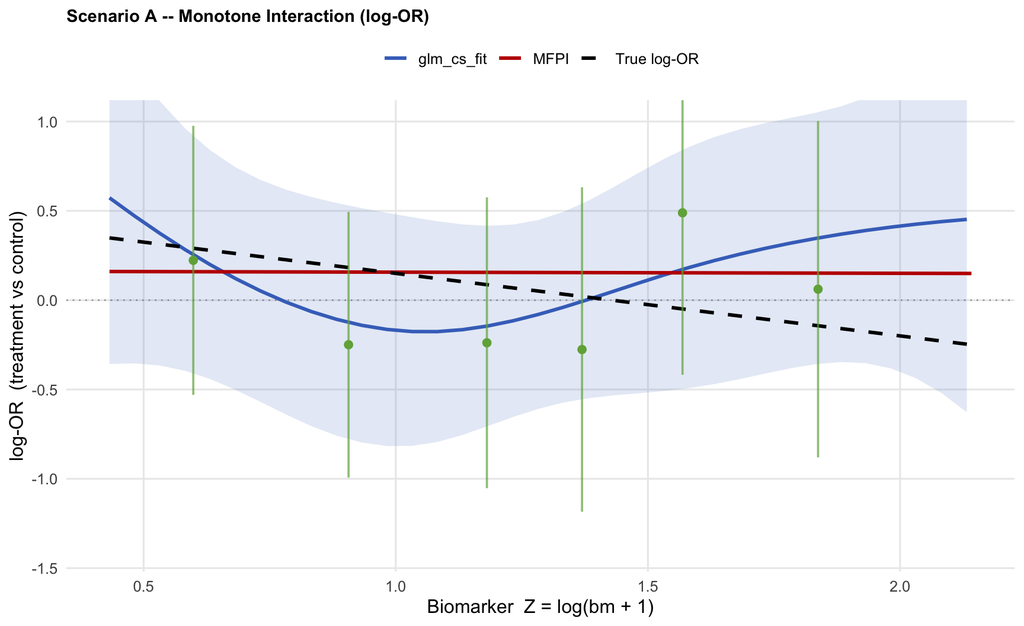

```r
plot_scenario_glm(sim_res$monotone, "Scenario A -- Monotone Interaction (log-OR)")
```

### 3.3.2 Scenario B – Threshold

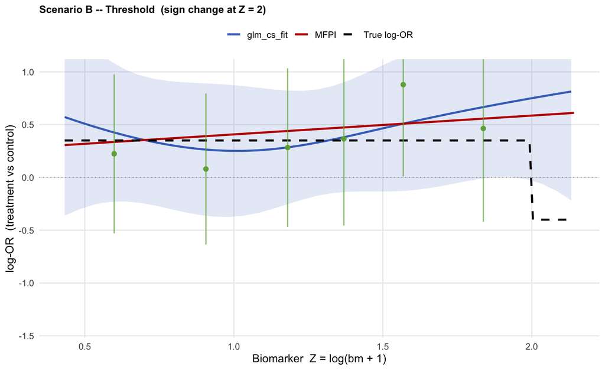

Scenario B: Sharp sign reversal at Z = 2. The spline smooths the discontinuity.

```r
plot_scenario_glm(sim_res$threshold,
                  "Scenario B -- Threshold  (sign change at Z = 2)")
```

### 3.3.3 Scenario C – Null

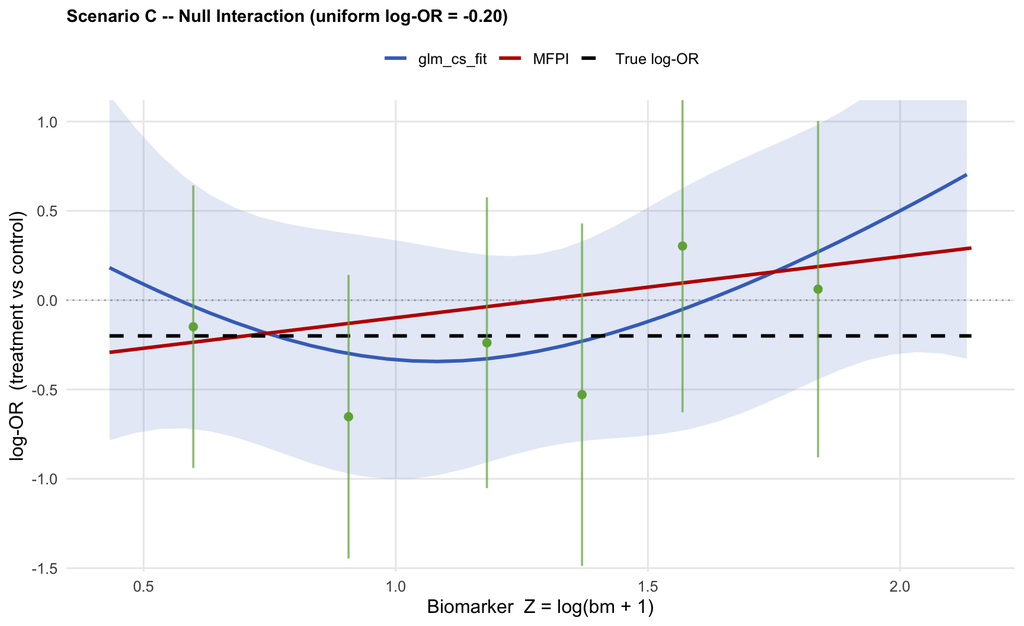

```r
plot_scenario_glm(sim_res$null,
                  "Scenario C -- Null Interaction (uniform log-OR = -0.20)")
```

### 3.3.4 Scenario D – Non-Monotone

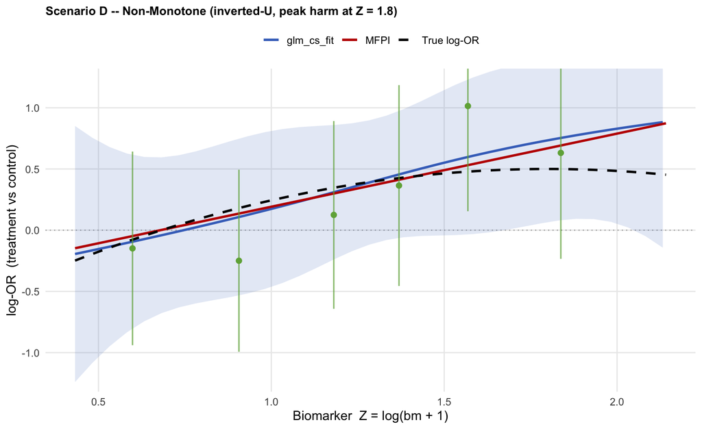

Scenario D: Inverted-U interaction. Harm peaks near Z = 1.8.

```r
plot_scenario_glm(sim_res$nonmonotone,
                  "Scenario D -- Non-Monotone (inverted-U, peak harm at Z = 1.8)",
                  ylim = c(-1.2, 1.2))
```

# 4 Joint Simulation Evaluation: `glm_cs_fit()` and STEPP-GLM

## 4.1 Simulation Metrics

Across $B =$ 2000 simulated trials at the grid `z_eval`:

| Quantity | Definition | Target |
| --- | --- | --- |
| **Bias** | $\bar{\hat\beta}(z) - \beta_0(z)$ | 0 |
| **Empirical SE** | $\text{SD}(\hat\beta_b(z))$ | – |
| **Mean estimated SE** | Mean delta-method / Wald SE | – |
| **SE ratio** | Mean est. SE / Empirical SE | 1.0 |
| **Coverage** | Prop. of 95% CIs containing truth | 0.95 |
| **Mean CI width** | Average interval width | – |

## 4.2 Simulation Engine

```r
compute_sim_summary_glm <- function(mat_est, mat_se, mat_lo, mat_hi,
                                    true_fn, z_eval, scenario) {
  mean_est <- colMeans(mat_est, na.rm = TRUE)
  bias_abs <- mean_est - true_fn
  rel_bias <- ifelse(abs(true_fn) >= 0.05, bias_abs / abs(true_fn), NA_real_)
  emp_se   <- apply(mat_est, 2, sd, na.rm = TRUE)
  mean_se  <- colMeans(mat_se, na.rm = TRUE)
  ci_width <- colMeans(mat_hi - mat_lo, na.rm = TRUE)
  covered  <- sweep(mat_lo, 2, true_fn, "<=") &
              sweep(mat_hi, 2, true_fn, ">=")

  data.frame(
    z = z_eval, true_logor = round(true_fn, 3),
    n_valid = colSums(!is.na(mat_est)),
    bias = round(bias_abs, 3), rel_bias = round(rel_bias, 3),
    mean_est = round(mean_est, 3), emp_se = round(emp_se, 3),
    mean_se = round(mean_se, 3),
    se_ratio = round(mean_se / emp_se, 3),
    coverage = round(colMeans(covered, na.rm = TRUE), 3),
    ci_width = round(ci_width, 3),
    scenario = scenario, stringsAsFactors = FALSE
  )
}

run_joint_eval_glm <- function(scenario,
                               B          = sim_B_eval,
                               z_eval     = sim_z_eval,
                               alpha      = sim_alpha,
                               patspop    = sim_patspop,
                               minpatspop = sim_minpatspop,
                               n_workers  = sim_n_workers) {
  n_z <- length(z_eval)

  old_plan <- plan()
  on.exit(plan(old_plan), add = TRUE)
  plan(multisession, workers = n_workers)

  message(sprintf("run_joint_eval_glm [%s]: B = %d | workers = %d",
                  scenario, B, n_workers))

  t_sc <- proc.time()

  res_list <- foreach(
    b = seq_len(B), .combine = "c",
    .options.future = list(seed = TRUE)
  ) %dofuture% {
    set.seed(b)
    library(forestsearch)
    library(splines)
    source(glm_source_path)

    d <- simulate_binary_trial(scenario = scenario, seed = b)

    na_out <- list(est = rep(NA_real_, n_z), se = rep(NA_real_, n_z),
                   lo  = rep(NA_real_, n_z), hi = rep(NA_real_, n_z))

    # -- glm_cs_fit --
    fit_gc <- tryCatch(
      glm_cs_fit(
        df = d, outcome_name = "event", treat_name = "treat",
        z_name = "Z", family = "binomial",
        spline_df = sim_spline_df, z_by = 0.05, z_quantile = 0.95,
        alpha = alpha, show_plot = FALSE, verbose = FALSE
      ),
      error = function(e) NULL
    )

    out_gc <- na_out
    if (!is.null(fit_gc)) {
      ok <- z_eval >= min(fit_gc$z_profile) & z_eval <= max(fit_gc$z_profile)
      if (any(ok)) {
        out_gc$est[ok] <- approx(fit_gc$z_profile, fit_gc$loghr_est,
                                  xout = z_eval[ok])$y
        out_gc$se[ok]  <- approx(fit_gc$z_profile, fit_gc$se_loghr,
                                  xout = z_eval[ok])$y
        out_gc$lo[ok]  <- approx(fit_gc$z_profile, fit_gc$loghr_lower,
                                  xout = z_eval[ok])$y
        out_gc$hi[ok]  <- approx(fit_gc$z_profile, fit_gc$loghr_upper,
                                  xout = z_eval[ok])$y
      }
    }

    # -- STEPP-GLM --
    fit_st <- tryCatch(
      stepp_windows_glm(
        df = d, bm_var = "Z", outcome_var = "event", treat_var = "treat",
        family = "binomial", patspop = patspop, minpatspop = minpatspop,
        conf_level = 1 - alpha
      ),
      error = function(e) NULL
    )

    out_st <- na_out
    if (!is.null(fit_st) && nrow(fit_st) >= 2L) {
      ok <- z_eval >= min(fit_st$mid_bm) & z_eval <= max(fit_st$mid_bm)
      if (any(ok)) {
        out_st$est[ok] <- approx(fit_st$mid_bm, fit_st$loghr,
                                  xout = z_eval[ok])$y
        out_st$se[ok]  <- approx(fit_st$mid_bm, fit_st$se_loghr,
                                  xout = z_eval[ok])$y
        out_st$lo[ok]  <- approx(fit_st$mid_bm, fit_st$lo,
                                  xout = z_eval[ok])$y
        out_st$hi[ok]  <- approx(fit_st$mid_bm, fit_st$hi,
                                  xout = z_eval[ok])$y
      }
    }

    list(list(gc = out_gc, st = out_st))
  }

  elapsed_sec <- round((proc.time() - t_sc)["elapsed"])

  # Assemble matrices
  mat_gc_est <- do.call(rbind, lapply(res_list, function(x) x$gc$est))
  mat_gc_se  <- do.call(rbind, lapply(res_list, function(x) x$gc$se))
  mat_gc_lo  <- do.call(rbind, lapply(res_list, function(x) x$gc$lo))
  mat_gc_hi  <- do.call(rbind, lapply(res_list, function(x) x$gc$hi))

  mat_st_est <- do.call(rbind, lapply(res_list, function(x) x$st$est))
  mat_st_se  <- do.call(rbind, lapply(res_list, function(x) x$st$se))
  mat_st_lo  <- do.call(rbind, lapply(res_list, function(x) x$st$lo))
  mat_st_hi  <- do.call(rbind, lapply(res_list, function(x) x$st$hi))

  true_fn <- switch(scenario,
    monotone    = 0.5 - 0.35 * z_eval,
    threshold   = ifelse(z_eval < 2.0, 0.35, -0.40),
    null        = rep(-0.20, n_z),
    nonmonotone = -0.40 * (z_eval - 1.8)^2 + 0.50
  )

  gcsf_sum  <- compute_sim_summary_glm(mat_gc_est, mat_gc_se,
                                        mat_gc_lo, mat_gc_hi,
                                        true_fn, z_eval, scenario)
  stepp_sum <- compute_sim_summary_glm(mat_st_est, mat_st_se,
                                        mat_st_lo, mat_st_hi,
                                        true_fn, z_eval, scenario)

  list(
    gcsf  = list(summary = gcsf_sum,
                  mat_est = mat_gc_est, mat_se = mat_gc_se,
                  mat_lo  = mat_gc_lo,  mat_hi = mat_gc_hi,
                  true_fn = true_fn),
    stepp = list(summary = stepp_sum,
                  mat_est = mat_st_est, mat_se = mat_st_se,
                  mat_lo  = mat_st_lo,  mat_hi = mat_st_hi,
                  true_fn = true_fn),
    elapsed_sec = elapsed_sec, scenario = scenario, B = B
  )
}
```

## 4.3 Run Evaluation – All Four Scenarios

```r
t_joint_start <- proc.time()

eval_monotone    <- run_joint_eval_glm("monotone",    B = sim_B_eval)
eval_threshold   <- run_joint_eval_glm("threshold",   B = sim_B_eval)
eval_null        <- run_joint_eval_glm("null",        B = sim_B_eval)
eval_nonmonotone <- run_joint_eval_glm("nonmonotone", B = sim_B_eval)

t_joint_total <- round((proc.time() - t_joint_start)["elapsed"])
cat(sprintf("Joint evaluation complete: B = %d | 4 scenarios | %d sec\n",
            sim_B_eval, t_joint_total))
```

```
Joint evaluation complete: B = 2000 | 4 scenarios | 16 sec
```

## 4.4 `glm_cs_fit()` Results Table

```r
all_gcsf <- bind_rows(
  eval_monotone$gcsf$summary,
  eval_threshold$gcsf$summary,
  eval_null$gcsf$summary,
  eval_nonmonotone$gcsf$summary
) |>
  mutate(Scenario = case_match(scenario,
    "monotone"    ~ "A: Monotone",
    "threshold"   ~ "B: Threshold",
    "null"        ~ "C: Null",
    "nonmonotone" ~ "D: Non-Monotone"
  )) |>
  select(Scenario, z, true_logor, mean_est, bias, rel_bias,
         emp_se, mean_se, se_ratio, coverage, ci_width)

knitr::kable(all_gcsf,
             col.names = c("Scenario", "z", "log-OR", "Est", "Bias", "Rel Bias",
                           "Emp SE", "Mean SE", "SE Ratio", "Coverage", "CI Wid"),
             align = "lrrrrrrrrrrr", digits = 3)
```

glm_cs_fit() SE and coverage across B = 2000 simulations.

| Scenario | z | log-OR | Est | Bias | Rel Bias | Emp SE | Mean SE | SE Ratio | Coverage | CI Wid |
| --- | --- | --- | --- | --- | --- | --- | --- | --- | --- | --- |
| A: Monotone | 0.6 | 0.290 | 0.309 | 0.019 | 0.066 | 0.423 | 0.401 | 0.947 | 0.953 | 1.572 |
| A: Monotone | 0.8 | 0.220 | 0.232 | 0.012 | 0.056 | 0.365 | 0.351 | 0.961 | 0.944 | 1.375 |
| A: Monotone | 1.0 | 0.150 | 0.158 | 0.008 | 0.052 | 0.366 | 0.356 | 0.972 | 0.948 | 1.395 |
| A: Monotone | 1.2 | 0.080 | 0.087 | 0.007 | 0.084 | 0.313 | 0.308 | 0.985 | 0.949 | 1.209 |
| A: Monotone | 1.4 | 0.010 | 0.018 | 0.008 | NA | 0.304 | 0.302 | 0.993 | 0.951 | 1.183 |
| A: Monotone | 1.6 | -0.060 | -0.053 | 0.007 | 0.120 | 0.372 | 0.367 | 0.985 | 0.953 | 1.438 |
| A: Monotone | 1.8 | -0.130 | -0.129 | 0.001 | 0.010 | 0.399 | 0.391 | 0.980 | 0.950 | 1.532 |
| A: Monotone | 2.0 | -0.200 | -0.210 | -0.010 | -0.050 | 0.487 | 0.464 | 0.952 | 0.964 | 1.819 |
| B: Threshold | 0.6 | 0.350 | 0.360 | 0.010 | 0.029 | 0.420 | 0.398 | 0.947 | 0.952 | 1.561 |
| B: Threshold | 0.8 | 0.350 | 0.345 | -0.005 | -0.013 | 0.357 | 0.343 | 0.962 | 0.949 | 1.345 |
| B: Threshold | 1.0 | 0.350 | 0.349 | -0.001 | -0.002 | 0.355 | 0.346 | 0.977 | 0.956 | 1.358 |
| B: Threshold | 1.2 | 0.350 | 0.376 | 0.026 | 0.075 | 0.300 | 0.298 | 0.992 | 0.952 | 1.168 |
| B: Threshold | 1.4 | 0.350 | 0.401 | 0.051 | 0.146 | 0.289 | 0.287 | 0.992 | 0.949 | 1.124 |
| B: Threshold | 1.6 | 0.350 | 0.374 | 0.024 | 0.069 | 0.353 | 0.346 | 0.980 | 0.950 | 1.357 |
| B: Threshold | 1.8 | 0.350 | 0.260 | -0.090 | -0.257 | 0.374 | 0.368 | 0.984 | 0.944 | 1.443 |
| B: Threshold | 2.0 | -0.400 | 0.067 | 0.467 | 1.167 | 0.463 | 0.448 | 0.968 | 0.810 | 1.755 |
| C: Null | 0.6 | -0.200 | -0.205 | -0.005 | -0.026 | 0.473 | 0.440 | 0.930 | 0.952 | 1.725 |
| C: Null | 0.8 | -0.200 | -0.200 | 0.000 | -0.002 | 0.393 | 0.375 | 0.954 | 0.949 | 1.471 |
| C: Null | 1.0 | -0.200 | -0.197 | 0.003 | 0.013 | 0.390 | 0.379 | 0.971 | 0.947 | 1.485 |
| C: Null | 1.2 | -0.200 | -0.196 | 0.004 | 0.020 | 0.333 | 0.327 | 0.985 | 0.949 | 1.283 |
| C: Null | 1.4 | -0.200 | -0.196 | 0.004 | 0.019 | 0.313 | 0.312 | 0.995 | 0.951 | 1.223 |
| C: Null | 1.6 | -0.200 | -0.198 | 0.002 | 0.010 | 0.379 | 0.376 | 0.991 | 0.956 | 1.473 |
| C: Null | 1.8 | -0.200 | -0.203 | -0.003 | -0.013 | 0.403 | 0.399 | 0.992 | 0.955 | 1.566 |
| C: Null | 2.0 | -0.200 | -0.210 | -0.010 | -0.049 | 0.479 | 0.462 | 0.965 | 0.965 | 1.812 |
| D: Non-Monotone | 0.6 | -0.076 | -0.086 | -0.010 | -0.125 | 0.467 | 0.437 | 0.935 | 0.959 | 1.712 |
| D: Non-Monotone | 0.8 | 0.100 | 0.100 | 0.000 | -0.004 | 0.367 | 0.353 | 0.962 | 0.946 | 1.383 |
| D: Non-Monotone | 1.0 | 0.244 | 0.255 | 0.011 | 0.043 | 0.357 | 0.351 | 0.983 | 0.953 | 1.377 |
| D: Non-Monotone | 1.2 | 0.356 | 0.372 | 0.016 | 0.044 | 0.305 | 0.303 | 0.993 | 0.952 | 1.188 |
| D: Non-Monotone | 1.4 | 0.436 | 0.450 | 0.014 | 0.033 | 0.285 | 0.281 | 0.985 | 0.955 | 1.101 |
| D: Non-Monotone | 1.6 | 0.484 | 0.496 | 0.012 | 0.024 | 0.345 | 0.336 | 0.975 | 0.946 | 1.317 |
| D: Non-Monotone | 1.8 | 0.500 | 0.513 | 0.013 | 0.026 | 0.364 | 0.357 | 0.979 | 0.949 | 1.398 |
| D: Non-Monotone | 2.0 | 0.484 | 0.506 | 0.022 | 0.046 | 0.423 | 0.406 | 0.960 | 0.954 | 1.593 |

## 4.5 Coverage and SE Ratio Profiles

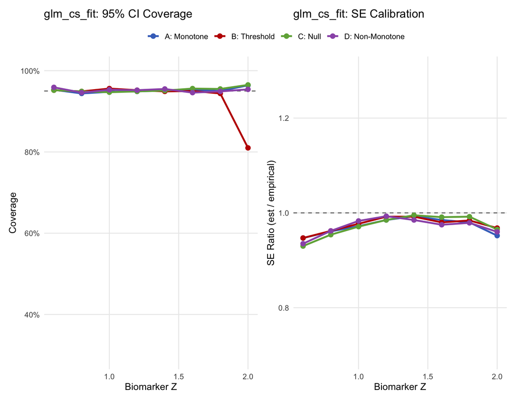

Left: Empirical coverage vs 95% target. Right: SE ratio; values near 1.0 confirm delta-method calibration.

```r
col_sc <- c("A: Monotone" = "#4472C4", "B: Threshold" = "#C00000",
            "C: Null"      = "#70AD47", "D: Non-Monotone" = "#9B59B6")

df_gcsf_plot <- all_gcsf |>
  mutate(Scenario = factor(Scenario,
    levels = c("A: Monotone", "B: Threshold", "C: Null", "D: Non-Monotone")))

p_cov <- ggplot(df_gcsf_plot, aes(x = z, y = coverage, colour = Scenario)) +
  geom_hline(yintercept = 1 - sim_alpha, linetype = "dashed",
             colour = "grey40") +
  geom_line(linewidth = 1.1) + geom_point(size = 2.5) +
  scale_colour_manual(values = col_sc, name = NULL) +
  scale_y_continuous(limits = c(0.3, 1), labels = percent_format(1)) +
  labs(x = "Biomarker Z", y = "Coverage",
       title = "glm_cs_fit: 95% CI Coverage") +
  theme_minimal(base_size = 12) +
  theme(legend.position = "top", panel.grid.minor = element_blank())

p_se <- ggplot(df_gcsf_plot, aes(x = z, y = se_ratio, colour = Scenario)) +
  geom_hline(yintercept = 1, linetype = "dashed", colour = "grey40") +
  geom_line(linewidth = 1.1) + geom_point(size = 2.5) +
  scale_colour_manual(values = col_sc, name = NULL) +
  scale_y_continuous(limits = c(0.7, 1.3)) +
  labs(x = "Biomarker Z", y = "SE Ratio (est / empirical)",
       title = "glm_cs_fit: SE Calibration") +
  theme_minimal(base_size = 12) +
  theme(legend.position = "top", panel.grid.minor = element_blank())

p_cov + p_se + plot_layout(ncol = 2, guides = "collect") &
  theme(legend.position = "top")
```

## 4.6 CI Width: `glm_cs_fit()` vs STEPP-GLM

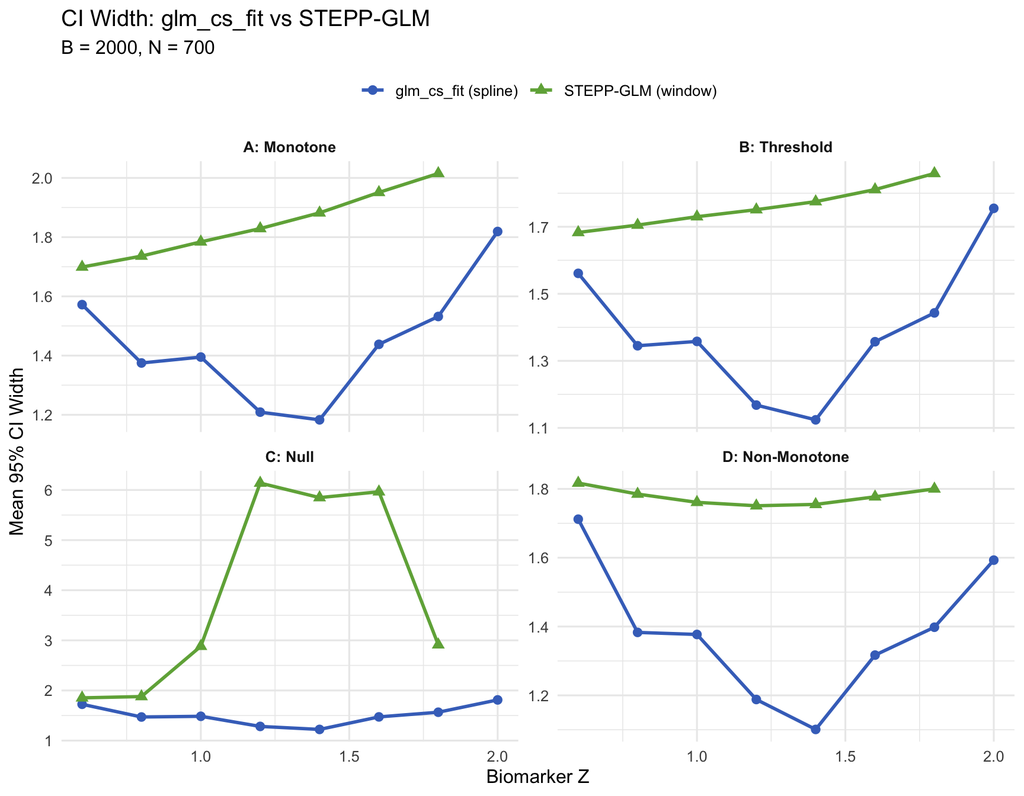

Mean 95% CI width across scenarios. The spline is substantially more efficient than STEPP-GLM.

```r
all_stepp_glm <- bind_rows(
  eval_monotone$stepp$summary,
  eval_threshold$stepp$summary,
  eval_null$stepp$summary,
  eval_nonmonotone$stepp$summary
) |>
  mutate(Scenario = case_match(scenario,
    "monotone"    ~ "A: Monotone",
    "threshold"   ~ "B: Threshold",
    "null"        ~ "C: Null",
    "nonmonotone" ~ "D: Non-Monotone"
  )) |>
  select(Scenario, z, true_logor, mean_est, bias, rel_bias,
         emp_se, mean_se, se_ratio, coverage, ci_width)

df_ciw <- bind_rows(
  mutate(all_gcsf, method = "glm_cs_fit (spline)"),
  mutate(all_stepp_glm, method = "STEPP-GLM (window)")
) |>
  mutate(Scenario = factor(Scenario,
    levels = c("A: Monotone", "B: Threshold", "C: Null", "D: Non-Monotone")))

ggplot(df_ciw, aes(x = z, y = ci_width, colour = method, shape = method)) +
  geom_line(linewidth = 1.0) + geom_point(size = 2.5) +
  facet_wrap(~ Scenario, ncol = 2, scales = "free_y") +
  scale_colour_manual(values = c("glm_cs_fit (spline)" = "#4472C4",
                                  "STEPP-GLM (window)"  = "#70AD47"),
                      name = NULL) +
  scale_shape_manual(values = c(16, 17), name = NULL) +
  labs(x = "Biomarker Z", y = "Mean 95% CI Width",
       title = "CI Width: glm_cs_fit vs STEPP-GLM",
       subtitle = sprintf("B = %d, N = %d", sim_B_eval, sim_n_trial)) +
  theme_minimal(base_size = 12) +
  theme(legend.position = "top", strip.text = element_text(face = "bold"))
```

# 5 To-Do: Poisson (Count) Extension

**ImportantPlanned Extension**

The following extensions are planned for a future update:

1. **GBSG Poisson Rate Analysis:** Use `event ~ treat + offset(log(rfstime))` to produce an IRR profile over PGR, comparing `glm_cs_fit(family = "poisson")` to the log-HR profile from `cox_cs_fit()`.
2. **STEPP with `stmodelGLM(glm = "poisson")`:** The `stepp` CRAN package already supports Poisson models via `stmodelGLM`. The `stepp_fit_glm()` wrapper defined in this vignette needs a `stmodelGLM` branch for `family = "poisson"` with offset support.
3. **Simulation with Rate-Based DGM:** Generate survival times from a Weibull model (as in the survival vignette), then analyze the binary event indicator with a Poisson offset model. Compare:
   - `cox_cs_fit()` log-HR profile
   - `glm_cs_fit(family = "poisson")` log-IRR profile
   - STEPP-GLM (Poisson) IRR profile
4. **Count Outcome DGM:** For genuine count data (not survival approximation), define a Poisson DGM: $Y_i \sim \text{Pois}(\mu_i)$ where $\log(\mu_i) = \alpha + \beta_0 Z_i + g(Z_i) A_i + \log(t_i)$. This would evaluate the methods on a native count-data problem.
5. **Package integration:** The `stepp_fit_glm()` and `stepp_windows_glm()` functions defined inline in this vignette should be exported from `forestsearch` once validated, paralleling the existing `stepp_fit()` / `stepp_windows()` for survival.

# 6 Session Information

```r
plan(sequential)
```